# Simulation Results

### Global Unifrac_res by motif size

#### Size 2 motif

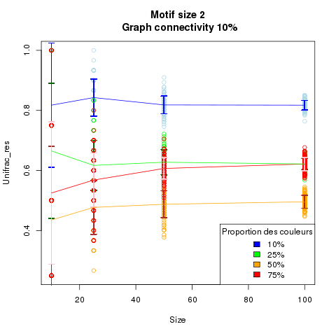

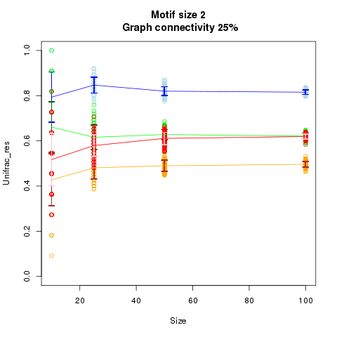

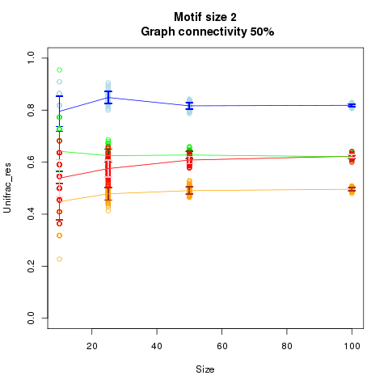

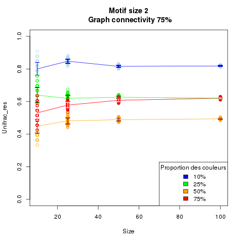

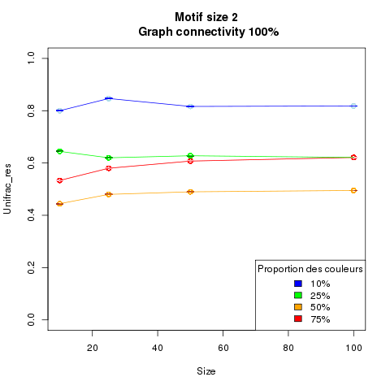

#### Size 3 motif

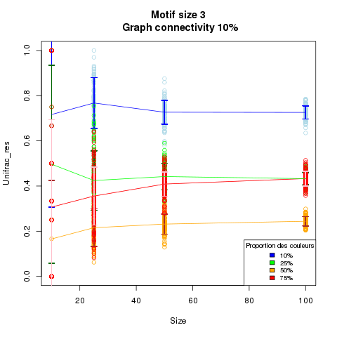

[figure not shown]

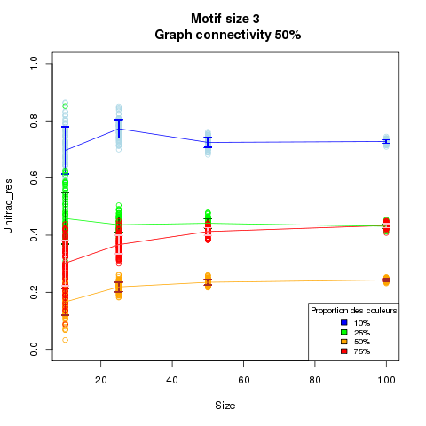

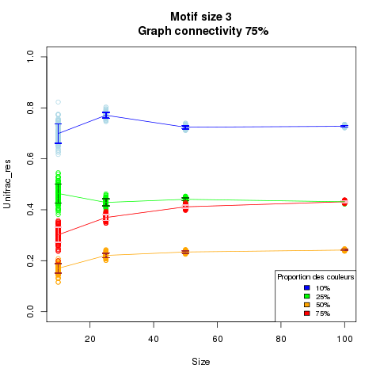

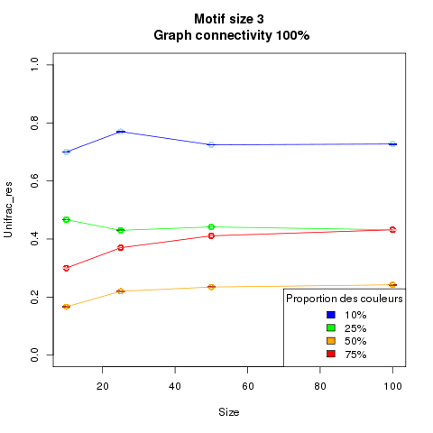

#### Size 4 motif

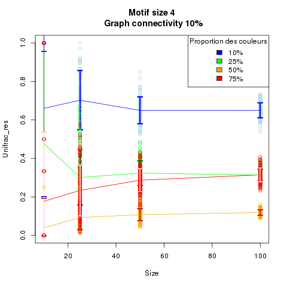

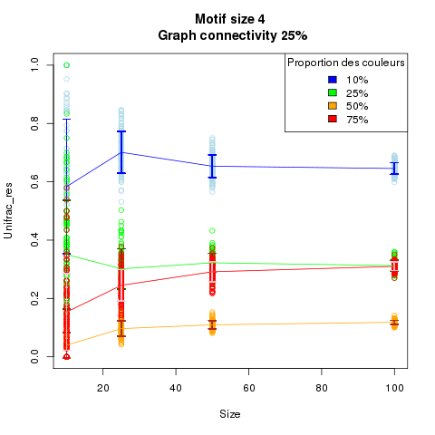

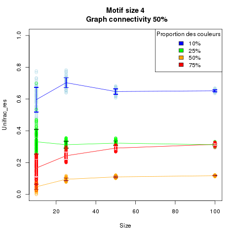

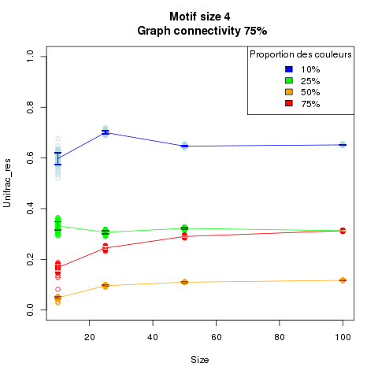

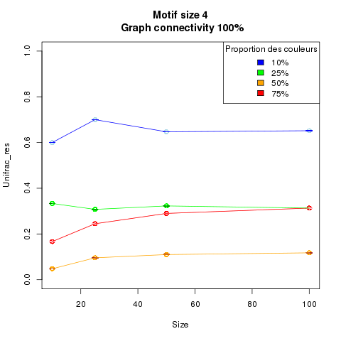